# examples_0521

This problem is based on the [polynomial remainder theorem](https://en.wikipedia.org/wiki/Polynomial_remainder_theorem). A polynomial function, $y=p(x)$, is plotted below.

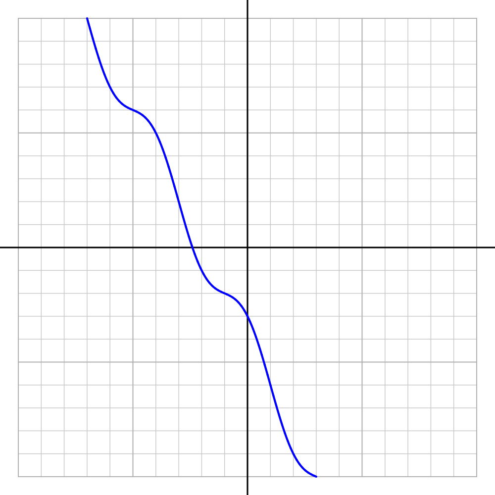

What is the remainder when $p(x)$ is divided by $x-1$?

The remainder theorem tells us that the remainder when $p(x)$ is divided by $x-1$ is equivalent to $p(1)$.

The curve goes through point $(1,-6)$. Thus, $p(1)=-6$.

So, the answer is -6.

This problem is based on the [polynomial remainder theorem](https://en.wikipedia.org/wiki/Polynomial_remainder_theorem). A polynomial function, $y=p(x)$, is plotted below.

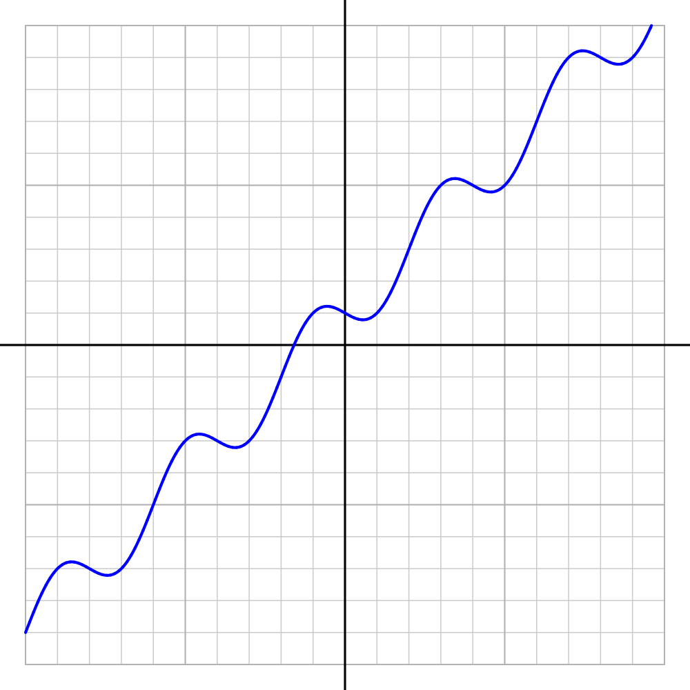

What is the remainder when $p(x)$ is divided by $x+3$?

The remainder theorem tells us that the remainder when $p(x)$ is divided by $x+3$ is equivalent to $p(-3)$.

The curve goes through point $(-3,-3)$. Thus, $p(-3)=-3$.

So, the answer is -3.

This problem is based on the [polynomial remainder theorem](https://en.wikipedia.org/wiki/Polynomial_remainder_theorem). A polynomial function, $y=p(x)$, is plotted below.

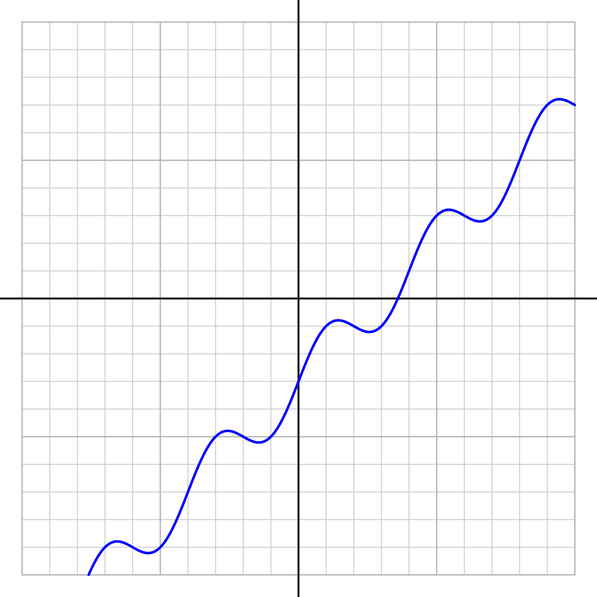

What is the remainder when $p(x)$ is divided by $x+7$?

The remainder theorem tells us that the remainder when $p(x)$ is divided by $x+7$ is equivalent to $p(-7)$.

The curve goes through point $(-7,-9)$. Thus, $p(-7)=-9$.

So, the answer is -9.

This problem is based on the [polynomial remainder theorem](https://en.wikipedia.org/wiki/Polynomial_remainder_theorem). A polynomial function, $y=p(x)$, is plotted below.

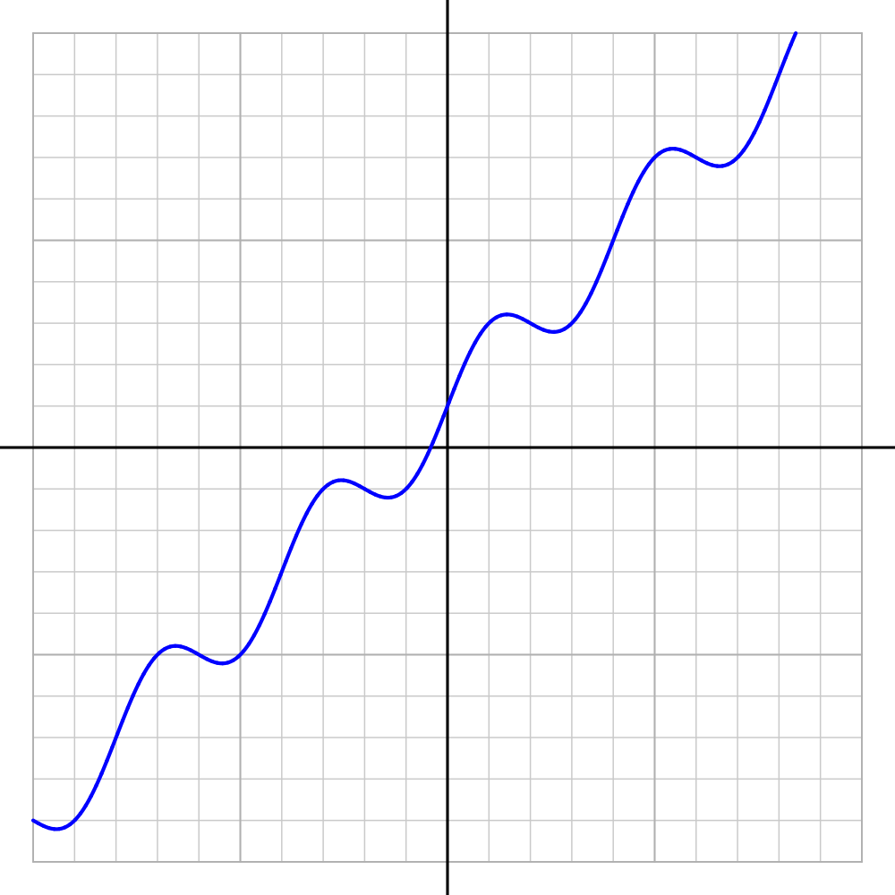

What is the remainder when $p(x)$ is divided by $x+7$?

The remainder theorem tells us that the remainder when $p(x)$ is divided by $x+7$ is equivalent to $p(-7)$.

The curve goes through point $(-7,-5)$. Thus, $p(-7)=-5$.

So, the answer is -5.

This problem is based on the [polynomial remainder theorem](https://en.wikipedia.org/wiki/Polynomial_remainder_theorem). A polynomial function, $y=p(x)$, is plotted below.

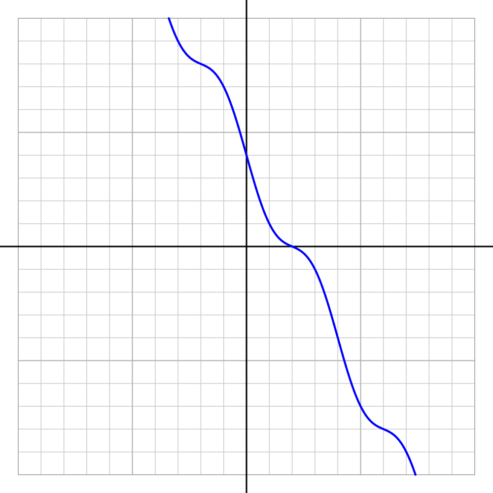

What is the remainder when $p(x)$ is divided by $x-1$?

The remainder theorem tells us that the remainder when $p(x)$ is divided by $x-1$ is equivalent to $p(1)$.

The curve goes through point $(1,1)$. Thus, $p(1)=1$.

So, the answer is 1.

This problem is based on the [polynomial remainder theorem](https://en.wikipedia.org/wiki/Polynomial_remainder_theorem). A polynomial function, $y=p(x)$, is plotted below.

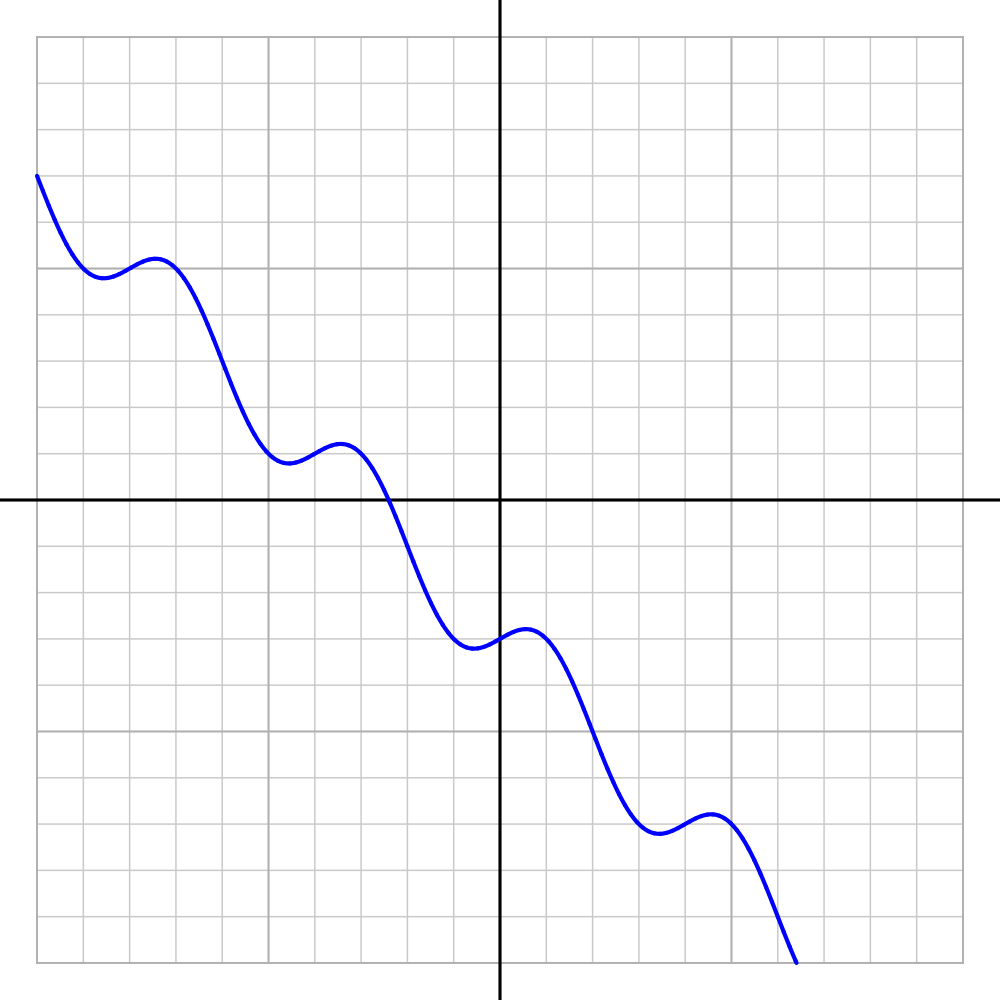

What is the remainder when $p(x)$ is divided by $x+6$?

The remainder theorem tells us that the remainder when $p(x)$ is divided by $x+6$ is equivalent to $p(-6)$.

The curve goes through point $(-6,3)$. Thus, $p(-6)=3$.

So, the answer is 3.

This problem is based on the [polynomial remainder theorem](https://en.wikipedia.org/wiki/Polynomial_remainder_theorem). A polynomial function, $y=p(x)$, is plotted below.

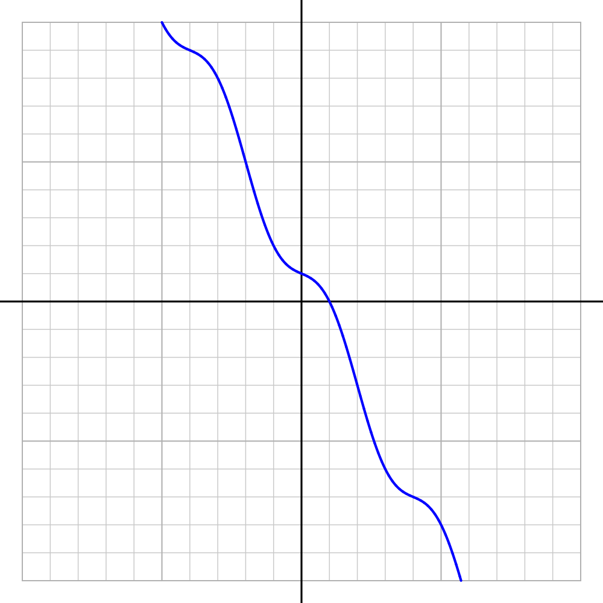

What is the remainder when $p(x)$ is divided by $x+3$?

The remainder theorem tells us that the remainder when $p(x)$ is divided by $x+3$ is equivalent to $p(-3)$.

The curve goes through point $(-3,8)$. Thus, $p(-3)=8$.

So, the answer is 8.

This problem is based on the [polynomial remainder theorem](https://en.wikipedia.org/wiki/Polynomial_remainder_theorem). A polynomial function, $y=p(x)$, is plotted below.

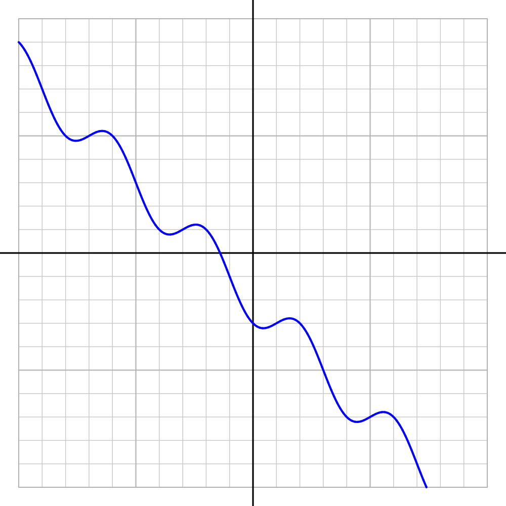

What is the remainder when $p(x)$ is divided by $x+4$?

The remainder theorem tells us that the remainder when $p(x)$ is divided by $x+4$ is equivalent to $p(-4)$.

The curve goes through point $(-4,1)$. Thus, $p(-4)=1$.

So, the answer is 1.

This problem is based on the [polynomial remainder theorem](https://en.wikipedia.org/wiki/Polynomial_remainder_theorem). A polynomial function, $y=p(x)$, is plotted below.

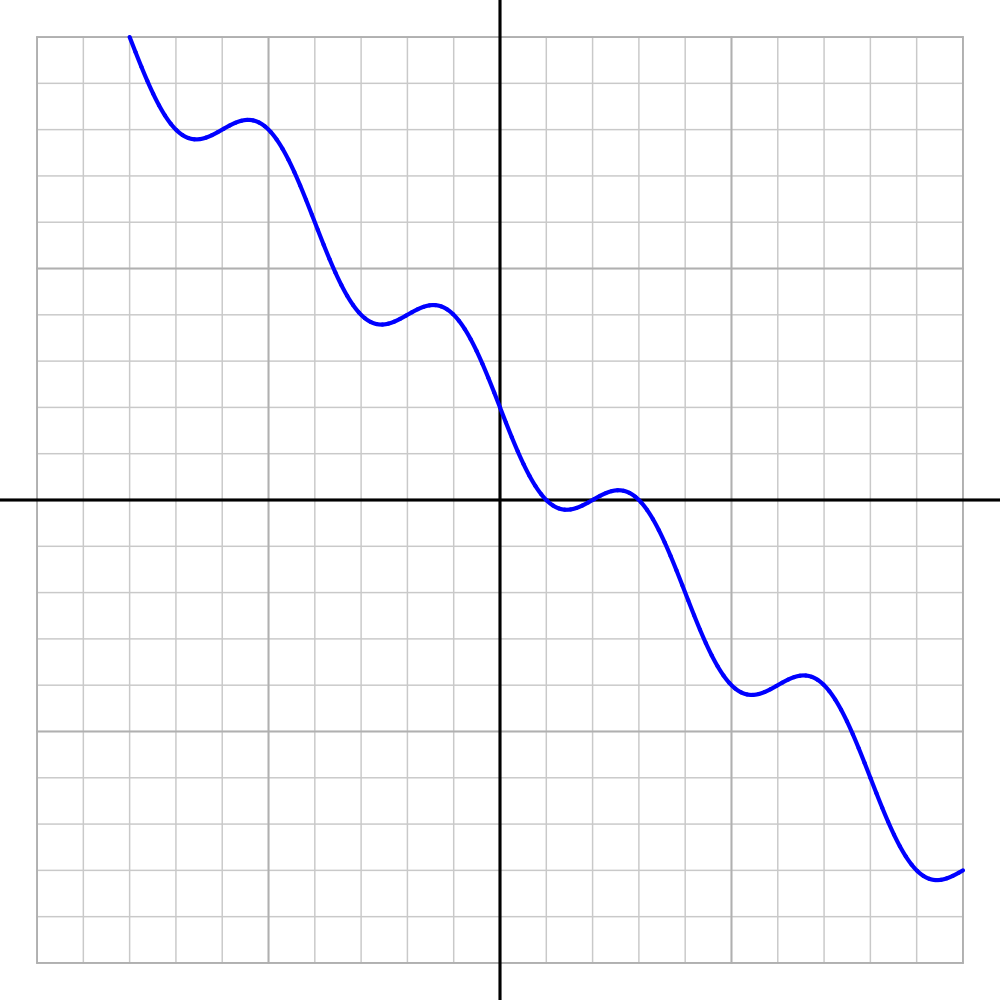

What is the remainder when $p(x)$ is divided by $x+5$?

The remainder theorem tells us that the remainder when $p(x)$ is divided by $x+5$ is equivalent to $p(-5)$.

The curve goes through point $(-5,8)$. Thus, $p(-5)=8$.

So, the answer is 8.

This problem is based on the [polynomial remainder theorem](https://en.wikipedia.org/wiki/Polynomial_remainder_theorem). A polynomial function, $y=p(x)$, is plotted below.

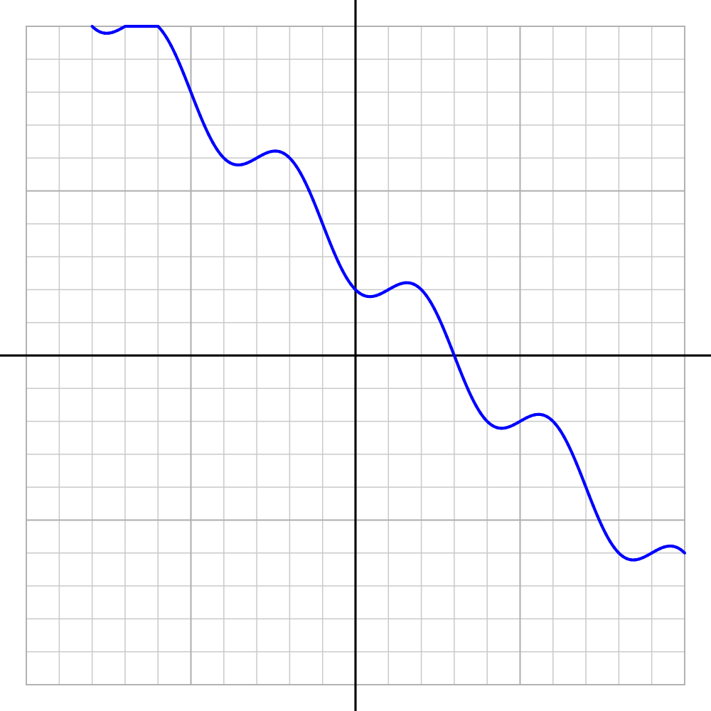

What is the remainder when $p(x)$ is divided by $x-4$?

The remainder theorem tells us that the remainder when $p(x)$ is divided by $x-4$ is equivalent to $p(4)$.

The curve goes through point $(4,-2)$. Thus, $p(4)=-2$.

So, the answer is -2.

This problem is based on the [polynomial remainder theorem](https://en.wikipedia.org/wiki/Polynomial_remainder_theorem). A polynomial function, $y=p(x)$, is plotted below.

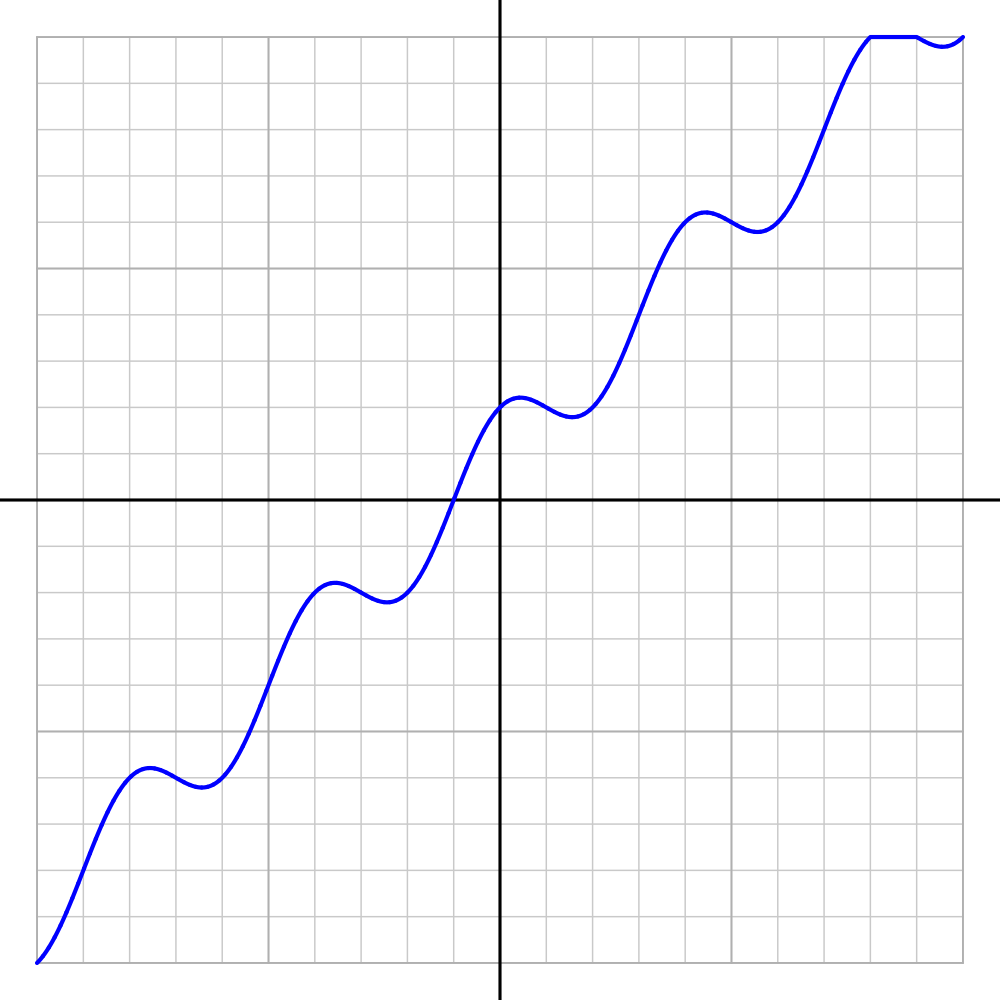

What is the remainder when $p(x)$ is divided by $x-4$?

The remainder theorem tells us that the remainder when $p(x)$ is divided by $x-4$ is equivalent to $p(4)$.

The curve goes through point $(4,6)$. Thus, $p(4)=6$.

So, the answer is 6.

This problem is based on the [polynomial remainder theorem](https://en.wikipedia.org/wiki/Polynomial_remainder_theorem). A polynomial function, $y=p(x)$, is plotted below.

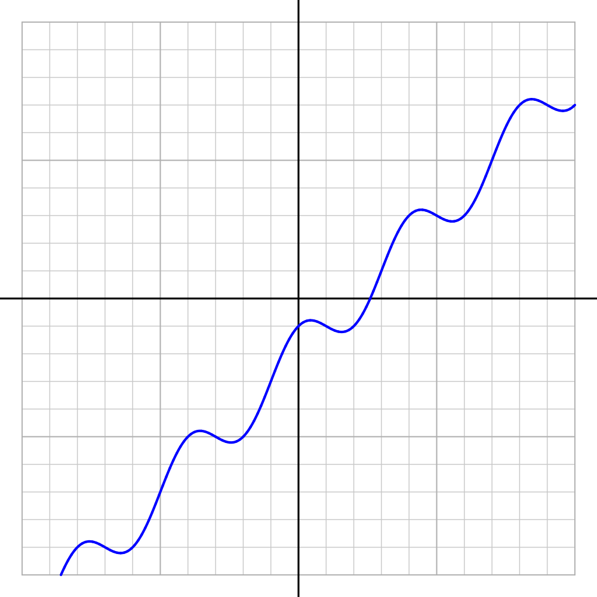

What is the remainder when $p(x)$ is divided by $x+8$?

The remainder theorem tells us that the remainder when $p(x)$ is divided by $x+8$ is equivalent to $p(-8)$.

The curve goes through point $(-8,-9)$. Thus, $p(-8)=-9$.

So, the answer is -9.

This problem is based on the [polynomial remainder theorem](https://en.wikipedia.org/wiki/Polynomial_remainder_theorem). A polynomial function, $y=p(x)$, is plotted below.

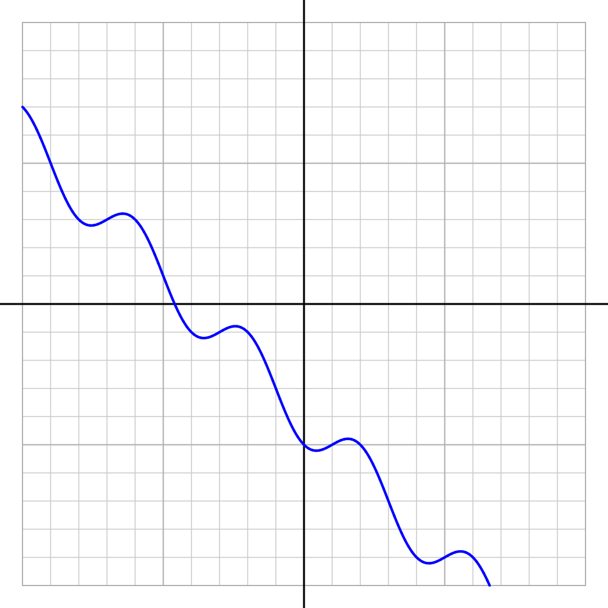

What is the remainder when $p(x)$ is divided by $x+4$?

The remainder theorem tells us that the remainder when $p(x)$ is divided by $x+4$ is equivalent to $p(-4)$.

The curve goes through point $(-4,-1)$. Thus, $p(-4)=-1$.

So, the answer is -1.

This problem is based on the [polynomial remainder theorem](https://en.wikipedia.org/wiki/Polynomial_remainder_theorem). A polynomial function, $y=p(x)$, is plotted below.

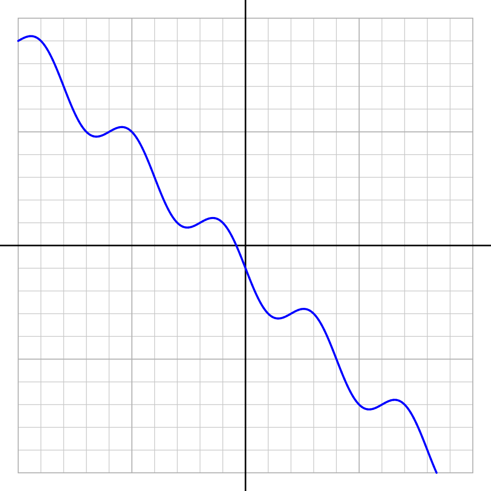

What is the remainder when $p(x)$ is divided by $x-3$?

The remainder theorem tells us that the remainder when $p(x)$ is divided by $x-3$ is equivalent to $p(3)$.

The curve goes through point $(3,-3)$. Thus, $p(3)=-3$.

So, the answer is -3.

This problem is based on the [polynomial remainder theorem](https://en.wikipedia.org/wiki/Polynomial_remainder_theorem). A polynomial function, $y=p(x)$, is plotted below.

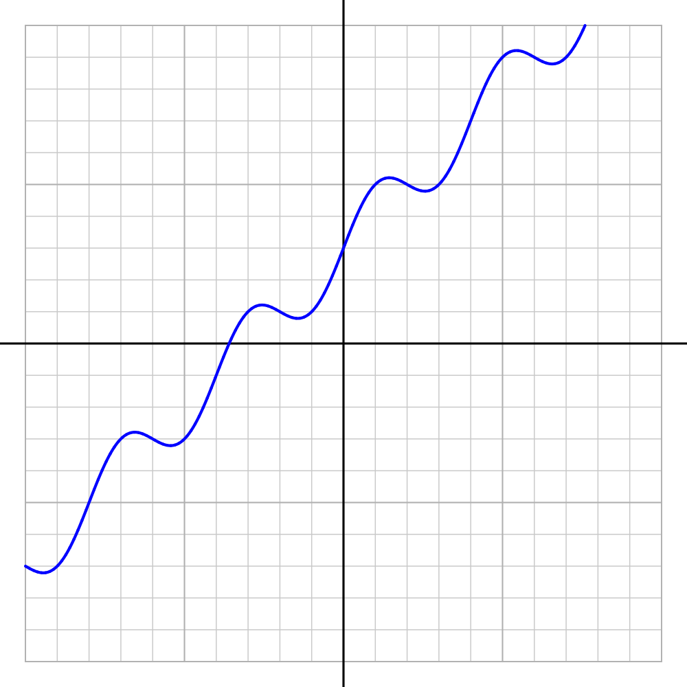

What is the remainder when $p(x)$ is divided by $x-2$?

The remainder theorem tells us that the remainder when $p(x)$ is divided by $x-2$ is equivalent to $p(2)$.

The curve goes through point $(2,5)$. Thus, $p(2)=5$.

So, the answer is 5.

This problem is based on the [polynomial remainder theorem](https://en.wikipedia.org/wiki/Polynomial_remainder_theorem). A polynomial function, $y=p(x)$, is plotted below.

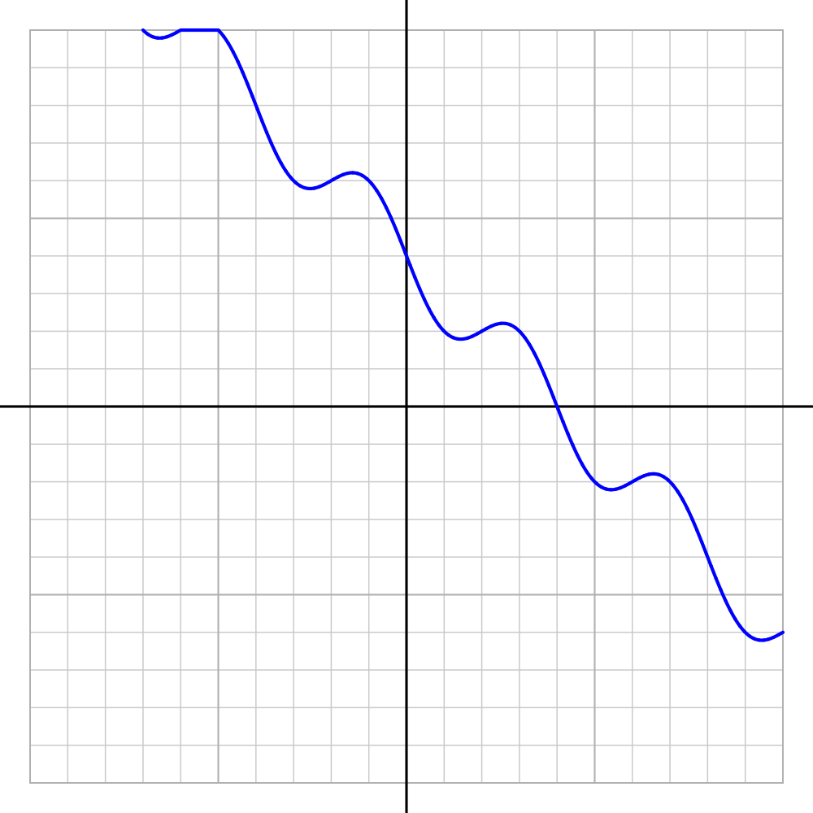

What is the remainder when $p(x)$ is divided by $x+2$?

The remainder theorem tells us that the remainder when $p(x)$ is divided by $x+2$ is equivalent to $p(-2)$.

The curve goes through point $(-2,6)$. Thus, $p(-2)=6$.

So, the answer is 6.

This problem is based on the [polynomial remainder theorem](https://en.wikipedia.org/wiki/Polynomial_remainder_theorem). A polynomial function, $y=p(x)$, is plotted below.

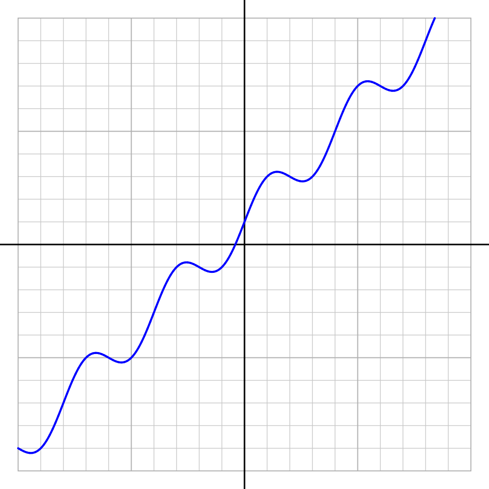

What is the remainder when $p(x)$ is divided by $x+4$?

The remainder theorem tells us that the remainder when $p(x)$ is divided by $x+4$ is equivalent to $p(-4)$.

The curve goes through point $(-4,-3)$. Thus, $p(-4)=-3$.

So, the answer is -3.

This problem is based on the [polynomial remainder theorem](https://en.wikipedia.org/wiki/Polynomial_remainder_theorem). A polynomial function, $y=p(x)$, is plotted below.

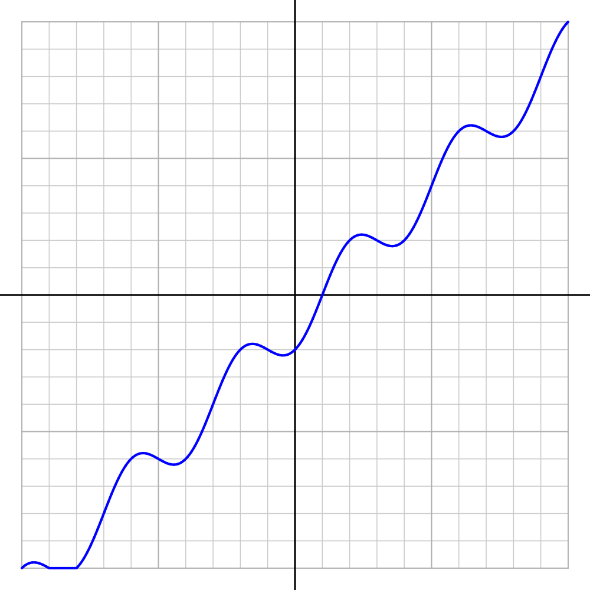

What is the remainder when $p(x)$ is divided by $x+7$?

The remainder theorem tells us that the remainder when $p(x)$ is divided by $x+7$ is equivalent to $p(-7)$.

The curve goes through point $(-7,-8)$. Thus, $p(-7)=-8$.

So, the answer is -8.

This problem is based on the [polynomial remainder theorem](https://en.wikipedia.org/wiki/Polynomial_remainder_theorem). A polynomial function, $y=p(x)$, is plotted below.

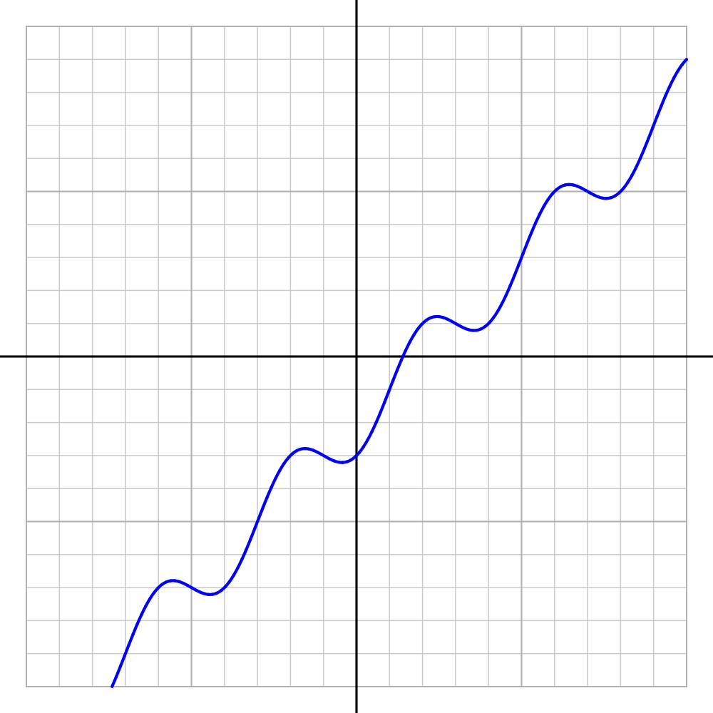

What is the remainder when $p(x)$ is divided by $x-2$?

The remainder theorem tells us that the remainder when $p(x)$ is divided by $x-2$ is equivalent to $p(2)$.

The curve goes through point $(2,1)$. Thus, $p(2)=1$.

So, the answer is 1.

This problem is based on the [polynomial remainder theorem](https://en.wikipedia.org/wiki/Polynomial_remainder_theorem). A polynomial function, $y=p(x)$, is plotted below.

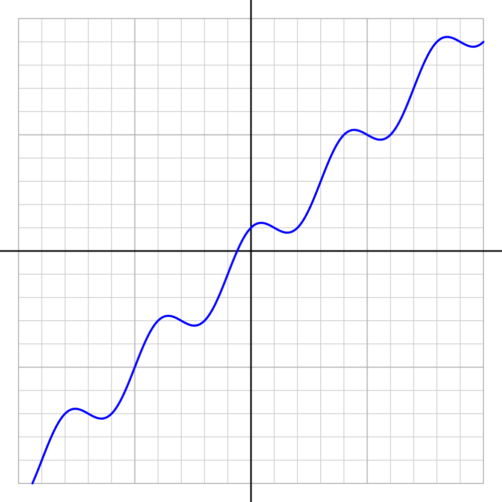

What is the remainder when $p(x)$ is divided by $x-7$?

The remainder theorem tells us that the remainder when $p(x)$ is divided by $x-7$ is equivalent to $p(7)$.

The curve goes through point $(7,7)$. Thus, $p(7)=7$.

So, the answer is 7.